Skip to contents

# Precipitation Perturbation Parameters

Source: [`vignettes/perturbation_parameters.qmd`](https://github.com/Deltares-research/weathergenr/blob/HEAD/vignettes/perturbation_parameters.qmd)

## 1 Purpose

Climate Perturbations shows *how* to apply a perturbation. This article asks a different question: given a target change, what do the remaining arguments actually do to the result?

Every scenario below imposes the same headline change — a 20% reduction in wet-day precipitation — and varies one argument at a time. Holding the target fixed is the point: differences between panels are the argument’s doing, not the scenario’s.

The site is stylized rather than real, so the mechanisms are visible without a region’s idiosyncrasies on top. Everything runs in a few seconds and no weather-generator call is involved.

> **What is not covered**

> `compute_pet` and `pet_method` are driven by temperature, not precipitation, and are covered in Climate Perturbations. `precip_cap_mm_day`, `precip_floor_mm_day` and `precip_cap_quantile` are safety rails applied after everything here, and do nothing until a bound is hit.

## 2 Setup

```r
library(weathergenr)
library(ggplot2)
library(dplyr)
library(tidyr)

theme_set(theme_weathergenr())
```

### 2.1 A stylized site

Thirty years of daily precipitation on a 365-day calendar, with a wet season from November to March, gamma-distributed wet-day amounts, and a slow interannual oscillation. That last ingredient matters: without year-to-year variability, one of the arguments below has nothing to act on and looks inert when it is not.

```r
n_years <- 30L
start_year <- 2000L

date <- as.Date("2000-01-01") + 0:(365L * n_years - 1L)
month <- as.integer(format(date, "%m"))
year_idx <- as.integer(format(date, "%Y")) - start_year + 1L

wet_prob <- c(0.55, 0.50, 0.45, 0.25, 0.15, 0.10,
              0.08, 0.10, 0.18, 0.30, 0.45, 0.55)[month]
wet_scale <- c(9, 8.5, 7.5, 5, 3.5, 2.5,
               2, 2.5, 4, 6, 8, 9)[month]

# A slow wet/dry oscillation, so the series has interannual structure.
ann_mult <- 1 + 0.35 * sin(2 * pi * seq_len(n_years) / 11)

set.seed(20260817)
precip <- numeric(length(date))
is_wet <- runif(length(date)) < wet_prob * ann_mult[year_idx]
precip[is_wet] <- rgamma(
  sum(is_wet),
  shape = 0.75,
  scale = wet_scale[is_wet] * ann_mult[year_idx][is_wet]
)
```

```r
tibble(
  days           = length(precip),
  wet_days       = sum(precip > 0),
  wet_fraction   = mean(precip > 0),
  annual_mm      = mean(tapply(precip, year_idx, sum)),
  wetday_mean_mm = mean(precip[precip > 0])
)
```

```
# A tibble: 1 × 5
   days wet_days wet_fraction annual_mm wetday_mean_mm
  <int>    <int>        <dbl>     <dbl>          <dbl>
1 10950     3335        0.305      629.           5.66
```

### 2.2 Instruments and metrics

The shape arguments belong to `adjust_precipitation_qm()`, the quantile mapper that `apply_climate_perturbations()` calls internally. Going straight to it keeps the grid and temperature scaffolding out of the way. The two `*_transient` arguments exist only on the wrapper, so Section 6 switches instruments.

Note the one interface difference: the wrapper accepts a length-12 vector and expands it, while the mapper requires an `n_years x 12` matrix.

```r
# The mapper wants a matrix; expand a monthly vector to one.
as_factor_matrix <- function(v) {
  matrix(v, nrow = n_years, ncol = 12, byrow = TRUE)
}

perturb <- function(mean_factor = 0.8, var_factor = 1, ...) {
  adjust_precipitation_qm(
    precip      = precip,
    month       = month,
    year        = year_idx,
    mean_factor = as_factor_matrix(rep(mean_factor, 12)),
    var_factor  = as_factor_matrix(rep(var_factor, 12)),
    validate_output = FALSE,
    diagnostics     = FALSE,
    verbose         = FALSE,
    ...
  )
}
```

Four metrics, chosen so the arguments separate rather than overlap. The last two are the ones that matter most, and pooling them — as a single overall coefficient of variation would — hides exactly the distinction Section 4 draws.

```r
wet_of <- function(x) x[x > 0]

# Groups are (month, year), the unit the perturbation itself works on.
by_group <- function(x) {
  w <- x > 0
  g <- split(x[w], list(month[w], year_idx[w]), drop = TRUE)
  g[lengths(g) >= 5]
}

summarise_series <- function(x, label) {
  g <- by_group(x)
  group_means <- vapply(g, mean, numeric(1))
  tibble(
    scenario    = label,
    wetday_mean = mean(wet_of(x)),
    p99         = unname(quantile(wet_of(x), 0.99)),
    # Spread of daily values inside a (month, year) group, averaged.
    within_cv   = mean(vapply(g, function(v) sd(v) / mean(v), numeric(1))),
    # Spread of the group means themselves: the interannual signal.
    between_cv  = sd(group_means) / mean(group_means)
  )
}
```

The baseline every scenario is measured against applies the 20% reduction with every other argument at its default.

```r
baseline <- perturb()

bind_rows(
  summarise_series(precip, "observed"),
  summarise_series(baseline, "baseline (-20%, defaults)")
)
```

```
# A tibble: 2 × 5
  scenario                  wetday_mean   p99 within_cv between_cv
  <chr>                           <dbl> <dbl>     <dbl>      <dbl>
1 observed                         5.66  36.3      1.06      0.471
2 baseline (-20%, defaults)        4.53  25.0      1.06      0.281
```

## 3 The headline: two ways to make extremes worse

`exaggerate_extremes` amplifies the upper tail. `enforce_target_mean` rescales each (month, year) group so its wet-day mean hits the target exactly. They are usually described separately, but the second decides what the first *means*.

```r
grid_2x2 <- expand.grid(
  exaggerate = c(FALSE, TRUE),
  enforce    = c(TRUE, FALSE)
)

do.call(bind_rows, lapply(seq_len(nrow(grid_2x2)), function(i) {
  ex <- grid_2x2$exaggerate[i]
  en <- grid_2x2$enforce[i]
  summarise_series(
    perturb(exaggerate_extremes = ex, enforce_target_mean = en, extreme_k = 1.5),
    sprintf("exaggerate=%s, enforce=%s", ex, en)
  )
}))
```

```
# A tibble: 4 × 5
  scenario                        wetday_mean   p99 within_cv between_cv
  <chr>                                 <dbl> <dbl>     <dbl>      <dbl>
1 exaggerate=FALSE, enforce=TRUE         4.53  25.0      1.06      0.281
2 exaggerate=TRUE, enforce=TRUE          4.53  31.6      1.17      0.281
3 exaggerate=FALSE, enforce=FALSE        4.53  29.0      1.06      0.471
4 exaggerate=TRUE, enforce=FALSE         5.12  45.9      1.17      0.554
```

The target wet-day mean is 4.527 mm. Three of the four rows sit exactly on it. The fourth — amplification with `enforce_target_mean = FALSE` — overshoots by about 13%.

That is the whole interaction. Amplifying the tail moves probability mass upward, which *adds* water; the scenario then delivers a larger mean change than the one requested. `enforce_target_mean = TRUE` rescales the group back onto its target, so the same amplification instead *redistributes* water: more in the tail, less in the body, at the mean you asked for.

> **Which one you want is a modelling choice**

> Redistribution at a fixed mean is the usual intent for a stress test, because it keeps the mean-change axis interpretable. If you leave `enforce_target_mean = FALSE` while amplifying, the realized mean change is no longer the number in your scenario table.

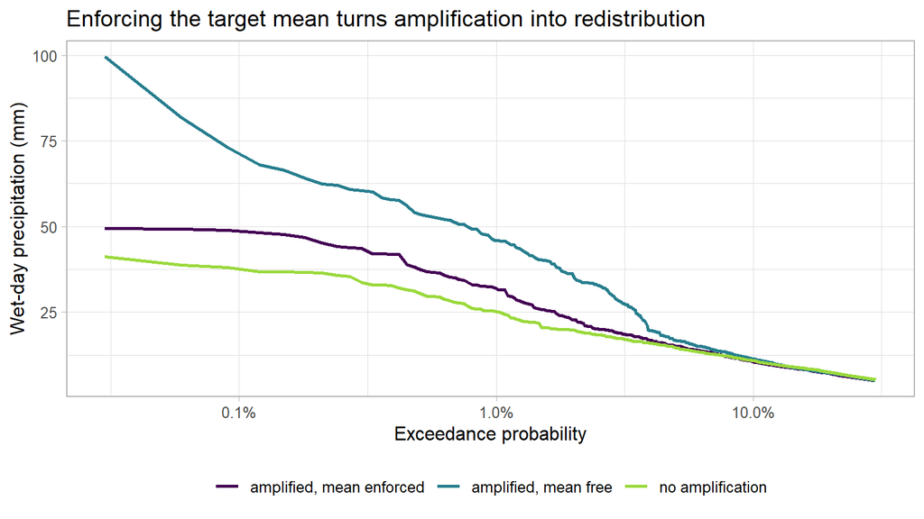

```r
exceedance <- function(x, label) {
  v <- sort(wet_of(x), decreasing = TRUE)
  tibble(value = v, prob = seq_along(v) / (length(v) + 1), scenario = label)
}

bind_rows(
  exceedance(baseline, "no amplification"),
  exceedance(perturb(exaggerate_extremes = TRUE, enforce_target_mean = TRUE,
                     extreme_k = 1.5), "amplified, mean enforced"),
  exceedance(perturb(exaggerate_extremes = TRUE, enforce_target_mean = FALSE,
                     extreme_k = 1.5), "amplified, mean free")
) |>
  filter(prob < 0.3) |>
  ggplot(aes(prob, value, colour = scenario)) +
  geom_line(linewidth = 0.9) +
  scale_x_log10(labels = scales::percent) +
  scale_colour_viridis_d(end = 0.85) +
  labs(
    title = "Enforcing the target mean turns amplification into redistribution",
    x = "Exceedance probability", y = "Wet-day precipitation (mm)",
    colour = NULL
  ) +
  theme(legend.position = "bottom")
```

### 3.1 How hard to amplify: `extreme_k`

With the mean enforced, `extreme_k` is a clean dial. Values above 1 amplify, values below 1 dampen, and 1 is the identity.

```r
k_values <- c(0.6, 0.8, 1.0, 1.2, 1.5, 2.0, 2.5)

k_sweep <- do.call(bind_rows, lapply(k_values, function(k) {
  summarise_series(
    perturb(exaggerate_extremes = TRUE, enforce_target_mean = TRUE, extreme_k = k),
    sprintf("k = %.1f", k)
  )
})) |>
  mutate(k = k_values, .before = 1)

k_sweep
```

```
# A tibble: 7 × 6
      k scenario wetday_mean   p99 within_cv between_cv
  <dbl> <chr>          <dbl> <dbl>     <dbl>      <dbl>
1   0.6 k = 0.6         4.53  20.0     0.963      0.281
2   0.8 k = 0.8         4.53  21.8     1.01       0.281
3   1   k = 1.0         4.53  25.0     1.06       0.281
4   1.2 k = 1.2         4.53  27.9     1.10       0.281
5   1.5 k = 1.5         4.53  31.6     1.17       0.281
6   2   k = 2.0         4.53  35.2     1.25       0.281
7   2.5 k = 2.5         4.53  39.4     1.32       0.281
```

The wet-day mean does not move across the whole sweep, while the 99th percentile roughly doubles. That is the response surface a stress test wants from a tail dimension: one axis, no side effects on the others.

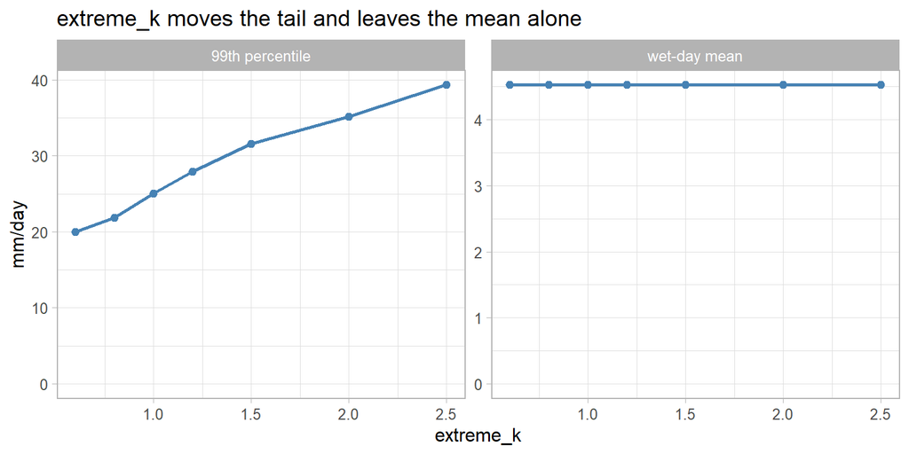

Figure 2: Tail severity against extreme_k, with the wet-day mean pinned by enforce_target_mean.

```r
k_sweep |>
  select(k, `99th percentile` = p99, `wet-day mean` = wetday_mean) |>
  pivot_longer(-k) |>
  ggplot(aes(k, value)) +
  geom_line(linewidth = 0.9, colour = "steelblue") +
  geom_point(size = 2, colour = "steelblue") +
  facet_wrap(~name, scales = "free_y") +
  expand_limits(y = 0) +
  labs(
    title = "extreme_k moves the tail and leaves the mean alone",
    x = "extreme_k", y = "mm/day"
  )
```

### 3.2 Where the tail starts: `extreme_prob_threshold`

`extreme_prob_threshold` sets the probability above which amplification applies. Its effect is less intuitive than `extreme_k`, and worth seeing before use.

```r
u0_values <- c(0.80, 0.90, 0.95, 0.99)

tail_quantiles <- function(x, label) {
  tibble(
    scenario = label,
    p90  = unname(quantile(wet_of(x), 0.90)),
    p99  = unname(quantile(wet_of(x), 0.99)),
    p999 = unname(quantile(wet_of(x), 0.999)),
    wetday_mean = mean(wet_of(x))
  )
}

bind_rows(
  tail_quantiles(baseline, "no amplification"),
  do.call(bind_rows, lapply(u0_values, function(u0) {
    tail_quantiles(
      perturb(exaggerate_extremes = TRUE, enforce_target_mean = TRUE,
              extreme_k = 1.5, extreme_prob_threshold = u0),
      sprintf("u0 = %.2f", u0)
    )
  }))
)
```

```
# A tibble: 5 × 5
  scenario           p90   p99  p999 wetday_mean
  <chr>            <dbl> <dbl> <dbl>       <dbl>
1 no amplification  10.9  25.0  36.8        4.53
2 u0 = 0.80         12.1  29.6  44.5        4.53
3 u0 = 0.90         10.9  29.4  45.8        4.53
4 u0 = 0.95         10.5  31.6  48.0        4.53
5 u0 = 0.99         10.6  26.5  47.7        4.53
```

Read the columns, not the rows. Lowering the threshold widens the affected region: at `u0 = 0.80` even the 90th percentile rises, because amplification has reached into the body of the distribution. Raising it concentrates the effect — at `u0 = 0.99` the 90th and 99th percentiles are barely touched while the 99.9th still moves.

The 99th percentile is not monotone across this sweep, which looks odd until you notice it sits *at* the threshold for the last row. With the mean enforced, widening the amplified region also forces a larger compensating rescale, so a given percentile can fall even as the far tail rises. Pick the threshold to match the return period you care about and read the quantile that matches it, rather than treating `u0` as a severity dial — that is `extreme_k`’s job.

## 4 Two knobs, two kinds of variability

`scale_var_with_mean` and `enforce_target_mean` both sound like they control “variability”, and a single pooled coefficient of variation would make them look like rivals. They are not: they act on different things, and the two `*_cv` columns separate them cleanly.

```r
knob_grid <- expand.grid(enforce = c(TRUE, FALSE), scale_var = c(TRUE, FALSE))

bind_rows(
  summarise_series(precip, "observed"),
  do.call(bind_rows, lapply(seq_len(nrow(knob_grid)), function(i) {
    en <- knob_grid$enforce[i]
    sv <- knob_grid$scale_var[i]
    summarise_series(
      perturb(enforce_target_mean = en, scale_var_with_mean = sv),
      sprintf("enforce=%s, scale_var=%s", en, sv)
    )
  }))
)
```

```
# A tibble: 5 × 5
  scenario                       wetday_mean   p99 within_cv between_cv
  <chr>                                <dbl> <dbl>     <dbl>      <dbl>
1 observed                              5.66  36.3      1.06      0.471
2 enforce=TRUE, scale_var=TRUE          4.53  25.0      1.06      0.281
3 enforce=FALSE, scale_var=TRUE         4.53  29.0      1.06      0.471
4 enforce=TRUE, scale_var=FALSE         4.53  30.3      1.29      0.281
5 enforce=FALSE, scale_var=FALSE        4.51  37.3      1.29      0.560
```

**`scale_var_with_mean` preserves the shape of a wet day.** When `TRUE`, the effective variance factor becomes `var_factor * mean_factor^2`, so the standard deviation scales with the mean and the coefficient of variation within a group is unchanged — it matches the observed value exactly. When `FALSE`, a `var_factor` of 1 holds absolute variance while the mean drops 20%, which inflates relative variability. Whether that is what you want depends on whether your scenario is “the same weather, less of it” or “the same absolute spread around a lower mean”.

> **The default trades away the variability the generator produces**

> `enforce_target_mean = TRUE` is the default, and it is the right default for hitting a scenario target exactly. But interannual variability is precisely what the WARM component of this package exists to generate, and pinning every year to a climatological target discards a large part of it.

> If your application is sensitive to sequences — multi-year drought, storage carry-over, anything with memory — check `between_cv` on your own output before accepting the default, and consider `enforce_target_mean = FALSE` with the realized mean change verified after the fact rather than imposed.

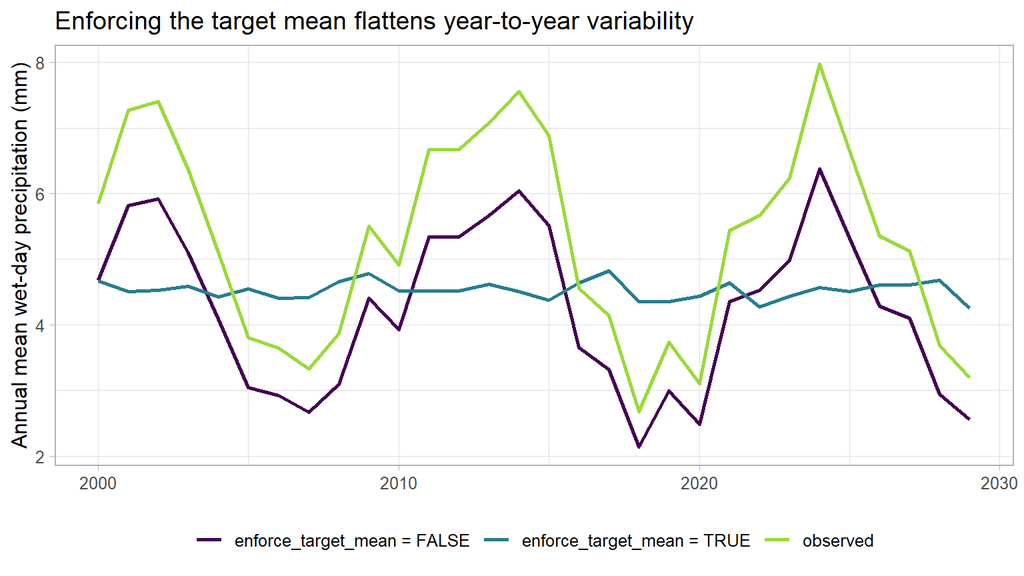

Figure 3: Annual mean wet-day precipitation. Enforcing the target mean flattens the interannual signal the observed series carries.

```r
annual_wetmean <- function(x, label) {
  tibble(
    year = start_year + seq_len(n_years) - 1L,
    value = vapply(split(x, year_idx), function(v) mean(v[v > 0]), numeric(1)),
    scenario = label
  )
}

bind_rows(
  annual_wetmean(precip, "observed"),
  annual_wetmean(perturb(enforce_target_mean = TRUE), "enforce_target_mean = TRUE"),
  annual_wetmean(perturb(enforce_target_mean = FALSE), "enforce_target_mean = FALSE")
) |>
  ggplot(aes(year, value, colour = scenario)) +
  geom_line(linewidth = 0.9) +
  scale_colour_viridis_d(end = 0.85) +
  labs(
    title = "Enforcing the target mean flattens year-to-year variability",
    x = NULL, y = "Annual mean wet-day precipitation (mm)", colour = NULL
  ) +
  theme(legend.position = "bottom")
```

## 5 Fitting: `qm_fit_method`

`qm_fit_method` chooses how the monthly Gamma distributions are estimated — `"mme"` (moment matching, the default) or `"mle"`.

```r
fit_mme <- perturb(fit_method = "mme")
fit_mle <- perturb(fit_method = "mle")

bind_rows(
  summarise_series(fit_mme, "mme"),
  summarise_series(fit_mle, "mle")
)
```

```
# A tibble: 2 × 5
  scenario wetday_mean   p99 within_cv between_cv
  <chr>          <dbl> <dbl>     <dbl>      <dbl>
1 mme             4.53  25.0      1.06      0.281
2 mle             4.53  25.0      1.06      0.281
```

The two rows are identical at the printed precision, so it is worth looking at the difference directly rather than at a rounded table:

```r
tibble(
  wetday_mean_difference = mean(wet_of(fit_mle)) - mean(wet_of(fit_mme)),
  largest_daily_difference = max(abs(fit_mle - fit_mme)),
  as_fraction_of_wetday_mean =
    max(abs(fit_mle - fit_mme)) / mean(wet_of(fit_mme))
)
```

```
# A tibble: 1 × 3
  wetday_mean_difference largest_daily_difference as_fraction_of_wetday_mean
                   <dbl>                    <dbl>                      <dbl>
1               0.000429                  0.00911                    0.00201
```

The wet-day means differ in the fourth decimal, and the largest single-day difference is a small fraction of a typical wet day. That is the honest result: on a well-behaved Gamma sample the two estimators effectively coincide. This is a robustness setting, not a scenario dimension — it earns attention when fitting is hard (short records, months with few wet days, heavily skewed samples), not as something to vary across a stress-test ensemble. `min_events`, which controls how many wet days a month needs before it is fitted at all, matters more often.

## 6 Transient versus step change

The `*_transient` arguments live on `apply_climate_perturbations()`, so this section uses the wrapper. That needs grid metadata and temperature columns, which the mapper did not.

```r
grid <- data.frame(id = 1L, lat = 0)

set.seed(7)
cell <- data.frame(
  precip   = precip,
  temp     = rnorm(length(date), 25, 3),
  temp_min = rnorm(length(date), 20, 3)
)
cell$temp_max <- pmax(cell$temp_min + 5, rnorm(length(date), 30, 3))
```

Occurrence shows this most clearly, because wet-day frequency is not touched by the mean-enforcement machinery above.

```r
wet_fraction_by_year <- function(x) {
  vapply(split(x, year_idx), function(v) mean(v > 0), numeric(1))
}
observed_fraction <- wet_fraction_by_year(precip)

run_occurrence <- function(transient) {
  out <- apply_climate_perturbations(
    data = list(cell), grid = grid, date = date,
    precip_mean_factor       = rep(1, 12),
    precip_occurrence_factor = rep(0.7, 12),
    temp_delta               = rep(0, 12),
    precip_transient             = FALSE,
    precip_occurrence_transient  = transient,
    temp_transient               = FALSE,
    compute_pet = FALSE, diagnostic = FALSE, verbose = FALSE, seed = 1L
  )
  tibble(
    year = start_year + seq_len(n_years) - 1L,
    ratio = as.numeric(wet_fraction_by_year(out[[1]]$precip) / observed_fraction),
    scenario = if (transient) "transient (ramp)" else "step change"
  )
}

occurrence_paths <- bind_rows(run_occurrence(FALSE), run_occurrence(TRUE))

occurrence_paths |>
  group_by(scenario) |>
  summarise(
    first_year = first(ratio), last_year = last(ratio), period_mean = mean(ratio)
  )
```

```
# A tibble: 2 × 4
  scenario         first_year last_year period_mean
  <chr>                 <dbl>     <dbl>       <dbl>
1 step change           0.688     0.697       0.696
2 transient (ramp)      1         0.394       0.705
```

Both average to the requested 0.7. The step change holds it flat; the ramp starts at no change and ends near 0.4.

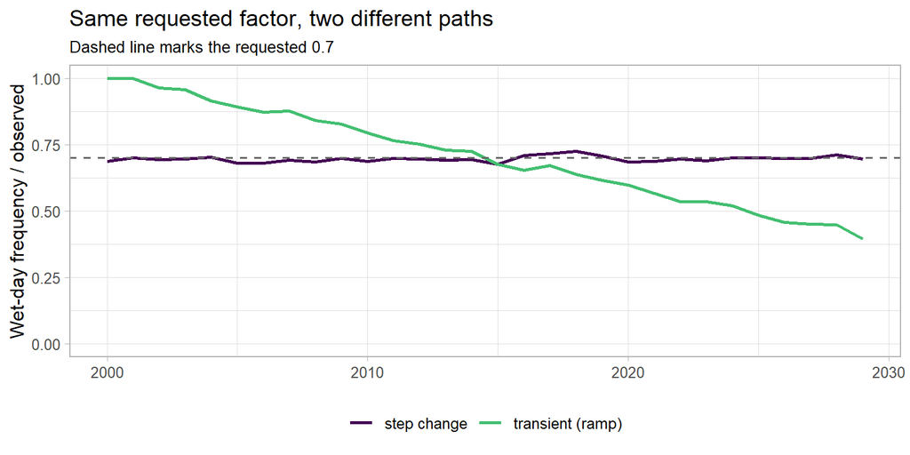

Figure 4: Wet-day frequency relative to observed, for a step change and a transient ramp requesting the same 0.7 factor.

```r
ggplot(occurrence_paths, aes(year, ratio, colour = scenario)) +
  geom_line(linewidth = 0.9) +
  geom_hline(yintercept = 0.7, linetype = "dashed", colour = "grey40") +
  scale_colour_viridis_d(end = 0.7) +
  expand_limits(y = 0) +
  labs(
    title = "Same requested factor, two different paths",
    subtitle = "Dashed line marks the requested 0.7",
    x = NULL, y = "Wet-day frequency / observed", colour = NULL
  ) +
  theme(legend.position = "bottom")
```

### 6.1 A transient factor takes a vector, not a year-varying matrix

Because the ramp is built from the end state, only the first row of a factor is read in transient mode. Supplying a year-varying `n_years x 12` matrix *and* setting the transient flag is therefore a contradiction, and is an error rather than a silent truncation:

```r
varying <- matrix(0.5, nrow = n_years, ncol = 12)
varying[1, ] <- 1.0

apply_climate_perturbations(
  data = list(cell), grid = grid, date = date,
  precip_mean_factor = varying,
  temp_delta = rep(0, 12),
  precip_transient = TRUE,
  compute_pet = FALSE, diagnostic = FALSE, verbose = FALSE
)
```

```
Error:
! 'precip_mean_factor' varies by year, but its transient flag is TRUE. A transient factor ramps from 1 to 2f-1 using row 1 alone, so rows 2:30 would be discarded. Supply a length-12 vector (the end-state change, whose ramp averages to it), or set the transient flag to FALSE to apply the matrix year …
```

Pass a length-12 vector and let the ramp build the path, or set the transient flag to `FALSE` to have the matrix applied year by year. A matrix whose rows are all identical is equivalent to a vector, so code that expanded a vector to a constant matrix is unaffected.

### 6.2 Intensity transients interact with the enforced mean

The same ramp applied to intensity is harder to read, and the reason is Section 4.

```r
observed_wetmean <- vapply(split(precip, year_idx),
                           function(v) mean(v[v > 0]), numeric(1))

run_intensity <- function(transient, enforce) {
  out <- apply_climate_perturbations(
    data = list(cell), grid = grid, date = date,
    precip_mean_factor  = rep(0.7, 12),
    temp_delta          = rep(0, 12),
    precip_transient    = transient,
    temp_transient      = FALSE,
    enforce_target_mean = enforce,
    compute_pet = FALSE, diagnostic = FALSE, verbose = FALSE, seed = 1L
  )
  realised <- vapply(split(out[[1]]$precip, year_idx),
                     function(v) mean(v[v > 0]), numeric(1))
  tibble(
    scenario = sprintf("transient=%s, enforce=%s", transient, enforce),
    year_1   = unname(realised / observed_wetmean)[1],
    year_30  = unname(realised / observed_wetmean)[n_years],
    period_mean = mean(realised / observed_wetmean)
  )
}

bind_rows(
  run_intensity(FALSE, TRUE), run_intensity(TRUE, TRUE),
  run_intensity(FALSE, FALSE), run_intensity(TRUE, FALSE)
)
```

```
# A tibble: 4 × 4
  scenario                       year_1 year_30 period_mean
  <chr>                           <dbl>   <dbl>       <dbl>
1 transient=FALSE, enforce=TRUE   0.698   1.17        0.814
2 transient=TRUE, enforce=TRUE    0.997   0.666       0.803
3 transient=FALSE, enforce=FALSE  0.7     0.7         0.7
4 transient=TRUE, enforce=FALSE   1       0.597       0.714
```

Neither is wrong — they are different definitions of the target. `enforce_target_mean = TRUE` means “the wet-day mean shall be 70% of climatology”; `FALSE` means “each year gets 70% of whatever it had”. For a transient scenario, where the point is a path through time, the second is usually the intended reading.

## 7 Choosing settings

A summary of what the article establishes, rather than new results.

| Argument | Controls | Reach for it when |
| --- | --- | --- |
| `exaggerate_extremes`, `extreme_k` | Tail severity at fixed mean | Extremes are a stress dimension of their own |
| `extreme_prob_threshold` | How much of the distribution counts as tail | The return period of interest is known |
| `enforce_target_mean` | Whether the mean is exact or emergent | `TRUE` to hit a target; `FALSE` to keep interannual structure |
| `scale_var_with_mean` | Wet-day shape under a mean change | `TRUE` for “same weather, less of it” |
| `qm_fit_method` | Gamma estimation | Fitting is hard; not a scenario axis |
| `precip_transient`, `precip_occurrence_transient` | Step change versus ramp to an end state | The scenario is a path, not a level |

Two defaults are worth a deliberate decision rather than acceptance. `enforce_target_mean = TRUE` buys exact targeting at the cost of interannual variability, which is the thing the generator upstream exists to produce. And `scale_var_with_mean = TRUE` is a statement that a drier climate has proportionally similar wet days — defensible, and still a statement.